# The effect of aging on visuomotor processes: Analyses and Results

Chad Vachon

Shanaathanan Modchalingam

Marius ’t Hart

Denise Henriques

# Preliminaries

Functions for R scripts that we need to use:

```r
source('R/learning_curves.R') # this file has all the data analysis stuff for learning curves
source('R/reach_aftereffects.R') # in this file we deal with reach aftereffects
source('R/localization.R') # scripts for localization stuff
source('R/shared.R') # color scheme, function for confidence intervals, data downloader
```

Check to see if data is present and if not, populate folder:

```r
ensureData()
```

```
## Checking if all data is available locally.
```

We’ll look at some participant descriptives first:

```r
participants <- checkParticipantsData()
# other analyses could be done with these demographics
groups <- aggregate(curves ~ group, data=participants, FUN=sum)
names(groups)[which(names(groups) == 'curves')] <- 'N'
groups$age_mean <- aggregate(age ~ group, data=participants, FUN=mean)$age
groups$age_std <- aggregate(age ~ group, data=participants, FUN=sd)$age
print(groups)
```

```
##            group  N age_mean  age_std
## 1     30explicit 21 21.38095 2.871867
## 2     30implicit 20 20.30000 2.735729
## 3 aging_explicit 19 69.89474 6.740382
## 4 aging_implicit 19 70.21053 7.004593
```

# Learning

In this section, we analyze how older and younger participants’ adapt their hand movements with or without instruction.  
Instructions should affect early learning for both age groups, but do they show whether instructions help older adults as much as younger adult?

## Was there any learning?

We want to know whether or not reach direction changed during the rotated training block for all groups and whether this varied with instruction type and age.

The following is a plot of the reaching data:

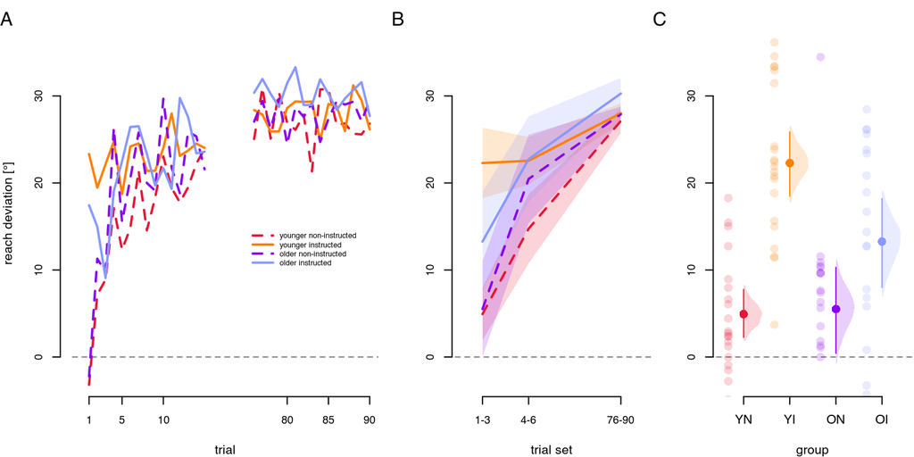

```r
# produce a plot (current Figure 3)
plotLearningCurves()
```

Reach deviations of 30 degrees would fully counter the rotation, so it looks like all groups learned, that instruction helped, but also that older adults perhaps benefit less from the instructions.

We do a three-way mixed ANOVA on reach deviations, using block (first, second and last), instructed (non-instructed or instructed) and agegroup (younger or older) as factors.

```r
# do a statistical analysis (omnibus ANOVA)
learningCurveANOVA()
```

```
## $ANOVA
##                      Effect DFn DFd            F            p p<.05
## 2                instructed   1  75 36.873548309 4.793719e-08     *
## 3                  agegroup   1  75  0.005703463 9.400011e-01
## 5                     block   2 150 94.808601285 2.413339e-27     *
## 4       instructed:agegroup   1  75  4.626676288 3.469957e-02     *
## 6          instructed:block   2 150 10.447872357 5.649380e-05     *
## 7            agegroup:block   2 150  4.818121112 9.375236e-03     *
## 8 instructed:agegroup:block   2 150  2.636804413 7.490674e-02
##            ges
## 2 1.499341e-01
## 3 2.728095e-05
## 5 4.477003e-01
## 4 2.165187e-02
## 6 8.200374e-02
```

[output cut: 21 more lines]

We find a significant effect of block (that interacts with instructions and age group) so that reach deviations changed throughout the rotated training. We also show that instruction type does interact with age group, so that older and younger participants learned differently in the training.

## First Block of Training

We had a specific prediction that instructed older adults would not benefit from the instructions as much as instructed younger adults. Here we want to see the effects of and interaction between age group and instruction, very early on in learning.

```r
blockLearningANOVA(block=1)
```

```
## Coefficient covariances computed by hccm()
```

```
## $ANOVA
##                Effect DFn DFd         F            p p<.05        ges
## 2          instructed   1  75 32.321222 2.373576e-07     * 0.30116338
## 3            agegroup   1  75  3.654923 5.972368e-02       0.04646782
## 4 instructed:agegroup   1  75  4.720148 3.297054e-02     * 0.05920897
##
## $`Levene's Test for Homogeneity of Variance`
##   DFn DFd      SSn      SSd        F         p p<.05
## 1   3  75 216.4871 3274.562 1.652794 0.1844402
```

There is an interaction between age group and instruction, so we want to test what causes this. Hence we do some follow-up tests. First a t-test looking to see if instruction had an effect within older adults.

```r
blockLearningTtest(block=1,
                   groups=list(
                     list('agegroup'='older', 'instructed'=TRUE),
                     list('agegroup'='older', 'instructed'=FALSE)))
```

```
##
## older instructed vs. older non-instructed
##
##  Welch Two Sample t-test
##
## data:  DVs[[1]] and DVs[[2]]
## t = 2.0608, df = 35.957, p-value = 0.04661
## alternative hypothesis: true difference in means is not equal to 0
## 95 percent confidence interval:
##   0.1228303 15.3955564
## sample estimates:
## mean of x mean of y
## 13.266212  5.507019
##
## eta squared: 0.10552
```

It appears, an instruction **did** benefit older adults. Therefore, we now want to see if it benefited older adults as much as younger adults:

```r
blockLearningTtest(block=1,
                   groups=list(
                     list('agegroup'='older', 'instructed'=TRUE),
                     list('agegroup'='younger', 'instructed'=TRUE)))
```

```
##
## older instructed vs. younger instructed
##
##  Welch Two Sample t-test
##
## data:  DVs[[1]] and DVs[[2]]
## t = -2.7073, df = 33.338, p-value = 0.01062
## alternative hypothesis: true difference in means is not equal to 0
## 95 percent confidence interval:
##  -15.799832  -2.244687
## sample estimates:
## mean of x mean of y
##  13.26621  22.28847
##
## eta squared: 0.16556
```

There is a difference in that older adults do not benefit from instruction as much as younger adults - at least in the first few trials.

## Second Block of Training

We wanted to see whether the effect of age and instruction would continue for the second block of trials. We repeat the ANOVA on reach deviations using age group and instruction as factors, but now on the data from the second block of three trials:

```r
blockLearningANOVA(block=2)
```

```
## Coefficient covariances computed by hccm()
```

```
## $ANOVA
##                Effect DFn DFd        F         p p<.05        ges
## 2          instructed   1  75 6.292251 0.0142871     * 0.07740284
## 3            agegroup   1  75 2.155170 0.1462722       0.02793294
## 4 instructed:agegroup   1  75 1.892170 0.1730519       0.02460809
##
## $`Levene's Test for Homogeneity of Variance`
##   DFn DFd      SSn     SSd        F         p p<.05
## 1   3  75 138.5701 2616.39 1.324058 0.2729033
```

Crucially, there is no effect of age group, nor an interaction between age group and instruction. Hence we skip any follow-ups: the benefit of instruction is not different for the two age groups in the second block of three trials.

# Reach Aftereffects

After training with a visual rotation, with or without instructions, people are more or less aware of the rotation that the experiment imposes on the visual feedback. To the degree that they are aware of what they are doing to reach to the target with altered feedback, they should also be able to “switch off” their strategy, which we test here with a PDP-like method (see Werner et al., 2015) by asking participants to reach with or without a strategy in the absence of visual feedback (“no-cursor” or “open-loop” reaches).

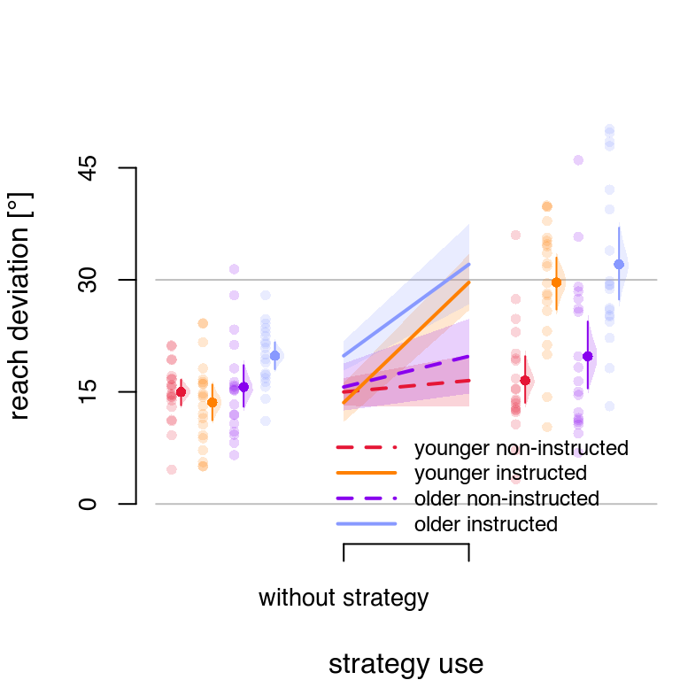

```r
# produce a plot (current Figure 4)
plotReachAftereffects()
```

## Are there reach aftereffects?

```r
NoCursorANOVA()
```

```
## $ANOVA
##                         Effect DFn DFd          F            p p<.05
## 2                   instructed   1  75   3.372444 7.025800e-02
## 3                     agegroup   1  75   1.565543 2.147443e-01
## 5                     training   1  75 746.928127 9.810769e-41     *
## 4          instructed:agegroup   1  75   6.121709 1.561388e-02     *
## 6          instructed:training   1  75   1.387715 2.425158e-01
## 7            agegroup:training   1  75   8.752309 4.134735e-03     *
## 8 instructed:agegroup:training   1  75   5.707561 1.940676e-02     *
##           ges
## 2 0.030464136
## 3 0.014376607
## 5 0.749990334
## 4 0.053958888
## 6 0.005542509
## 7 0.033957741
## 8 0.022409268
```

As expected there is a main effect of training, i.e. there were reach aftereffects. In other words: the participants adapted to the rotation. There were other effects which we will explore below, but we subtract aligned reach deviations from those in the rotated session.

It is also important to notice that while instruction interacted with age-group and with both age-group and session, it did not have a main effect or an interaction with instruction alone. This suggests that explicit learning, as induced by instruction did not decrease (implicit) reach aftereffects. To test this we ran two single-sided t-tests checking if reach aftereffects were smaller for the instructed as compared to the non-instructed participants for both age groups:

```r
NoCursorTtests()
```

```
## Older participants:
##
##  Welch Two Sample t-test
##
## data:  OlderINSTR and OlderNONIN
## t = 2.3549, df = 30.39, p-value = 0.9874
## alternative hypothesis: true difference in means is less than 0
## 95 percent confidence interval:
##      -Inf 7.192881
## sample estimates:
## mean of x mean of y
##  19.84034  15.65953
##
## eta-squared: 0.13348
##
## Younger participants:
##
##  Welch Two Sample t-test
##
## data:  YoungINSTR and YoungNONIN
## t = -0.92675, df = 35.892, p-value = 0.1801
## alternative hypothesis: true difference in means is less than 0
## 95 percent confidence interval:
##      -Inf 1.166605
## sample estimates:
## mean of x mean of y
##  13.57277  14.99218
##
## eta-squared: 0.02119
```

The lack of an effect suggests that explicit learning by instruction does not decrease reach aftereffects in either age group. Looking at the figure, it seems that instructed older adults even have slightly larger reach aftereffects than non-instructed older adults.

## Are reach aftereffects affected by strategy use in the four groups?

We test if the magnitude of reach aftereffects is different given age group or instruction, by doing a three-way, mixed design ANOVA on reach aftereffects with instructed (yes or no) and age group (older vs. younger) as between-subjects factors and strategy use (with or without) as a within-subjects factor:

```r
# do a statistical analysis (ANOVA on reach aftereffects)
RAE.ANOVA()
```

```
## $ANOVA
##                         Effect DFn DFd         F            p p<.05
## 2                   instructed   1  75 24.911294 3.786295e-06     *
## 3                     agegroup   1  75  4.977138 2.867356e-02     *
## 5                     strategy   1  75 79.701978 2.044180e-13     *
## 4          instructed:agegroup   1  75  0.710164 4.020688e-01
## 6          instructed:strategy   1  75 35.568793 7.527147e-08     *
## 7            agegroup:strategy   1  75  0.110363 7.406580e-01
## 8 instructed:agegroup:strategy   1  75  2.866369 9.459889e-02
##            ges
## 2 0.1860701534
## 3 0.0436793978
## 5 0.2488433531
## 4 0.0064748691
## 6 0.1287993687
## 7 0.0004585119
## 8 0.0117737510
```

[output not shown]

[output not shown]

```
## Contrasts set to contr.sum for the following variables: agegroup, instructed
```

```
## Anova Table (Type 3 tests)
##
## Response: reachdeviation
##                         Effect    df   MSE         F   ges p.value
## 1                     agegroup 1, 75 78.69    4.98 *   .04     .03
## 2                   instructed 1, 75 78.69 24.91 ***   .19  <.0001
## 3          agegroup:instructed 1, 75 78.69      0.71  .006     .40
## 4                     strategy 1, 75 35.64 79.70 ***   .25  <.0001
## 5            agegroup:strategy 1, 75 35.64      0.11 .0005     .74
## 6          instructed:strategy 1, 75 35.64 35.57 ***   .13  <.0001
## 7 agegroup:instructed:strategy 1, 75 35.64    2.87 +   .01     .09
## ---
## Signif. codes:  0 '***' 0.001 '**' 0.01 '*' 0.05 '+' 0.1 ' ' 1
```

Instruction and strategy have an effect and interact. When we look at the figure showing the magnitude of reach afterreffects, we can see that this means that when provided with an instruction, people can elicit part of their learning at will, i.e.: learning is (partially) made explicit by the instructions.

There is a main effect of age group, but more importantly, this doesn’t interact with instruction type (or strategy), so that we can say that the effect of instruction on explicit learning is the same for both age groups.

# Localization

To move we need to have position information on our limbs. In the absence of vision we can use proprioception as well efference-based predicted consequences. Both of these are changed with visuomotor training. Here we try to tease them apart with our passive and active localization task.

## Does localization change with training?

Here we assess whether older and younger adults differ in how they estimate the location of their hand after training. We also determine whether this is different when they have access only to proprioception (passive localization) compared to when they have access to prediction and proprioception (active localization). The difference between these two is the predicted consequences plot below.

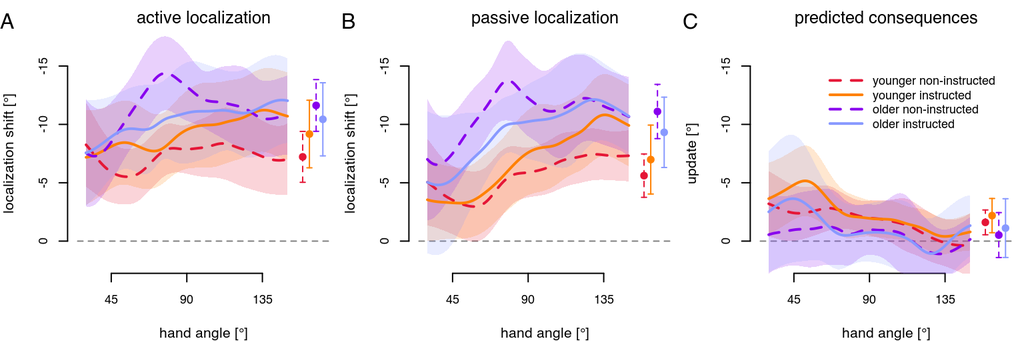

```r
# produce a plot: current Figure 5
plotLocalization()
```

We can see that all groups show some kind of shift in both active and passive localization, with perhaps larger shifts for the older adults (we’ll test this below). The third panel seems to show that younger adults may rely somewhat on predicted sensory consequences while older participants didn’t, but this needs testing (see below).

First we want to see if there is any effect of rotated training on localization, so we do an mixed-design “omnibus ANOVA” using rotated (no vs. yes), passive movement (no=active vs. yes=passive) as within-subject factors and age group (older vs. younger) and instruction (yes or no) as between-subject factors.

```r
# do a statistical analysis (omnibus ANOVA)
localizationANOVA()
```

```
## $ANOVA
##                                     Effect DFn DFd            F            p
## 2                               instructed   1  75 9.034756e-01 3.449045e-01
## 3                                 agegroup   1  75 7.072646e+00 9.564921e-03
## 5                                rotated_b   1  75 2.313452e+02 1.270599e-24
## 9                                passive_b   1  75 2.027385e-01 6.538183e-01
## 4                      instructed:agegroup   1  75 2.123208e-02 8.845394e-01
## 6                     instructed:rotated_b   1  75 5.854518e-03 9.392133e-01
## 7                       agegroup:rotated_b   1  75 8.242761e+00 5.315132e-03
## 10                    instructed:passive_b   1  75 7.350932e-02 7.870389e-01
## 11                      agegroup:passive_b   1  75 3.662387e-01 5.468885e-01
## 13                     rotated_b:passive_b   1  75 1.005777e+01 2.198283e-03
## 8            instructed:agegroup:rotated_b   1  75 1.799562e+00 1.838134e-01
## 12           instructed:agegroup:passive_b   1  75 9.925445e-04 9.749508e-01
## 14          instructed:rotated_b:passive_b   1  75 4.709471e-01 4.946679e-01
```

[output cut: 18 more lines]

Rotated training shifts localization. There are some other effects, that we will test in more depth later on. Either way, we now calculate localization shifts as the difference between aligned and rotated localization responses.

If explicit learning prevents updating predicted sensory consequences or recalibrating proprioception (since you **know** the feedback is not veridical) then instructions should affect localization shift. Also, if older participants use instructions differently, or if their proprioceptive acuity has decreased, age group should also affect localization shift. That is what we test here:

```r
# do a statistical analysis (ANOVA on passive localization difference scores)
localizationANOVA(test='shifts')
```

```
## $ANOVA
##                          Effect DFn DFd            F           p p<.05
## 2                    instructed   1  75 5.854518e-03 0.939213269
## 3                      agegroup   1  75 8.242761e+00 0.005315132     *
## 5                     passive_b   1  75 1.005777e+01 0.002198283     *
## 4           instructed:agegroup   1  75 1.799562e+00 0.183813420
## 6          instructed:passive_b   1  75 4.709471e-01 0.494667928
## 7            agegroup:passive_b   1  75 1.595244e+00 0.210491097
## 8 instructed:agegroup:passive_b   1  75 9.127579e-05 0.992402625
##            ges
## 2 6.891025e-05
## 3 8.844591e-02
## 5 1.546804e-02
## 4 2.074368e-02
## 6 7.351176e-04
## 7 2.485709e-03
## 8 1.425803e-07
```

There is a main effect of age as well as a main effect of movement type, but no interaction. That is, it seems that our observation that older adults had larger training-induced shifts of localization is true. The effect of passive versus active localization seems to suggest that (at least for some groups) active localization was influenced by predicted sensory consequences.

It is interesting to see that instruction has no effect. This means that any effect of instruction on hand localization is minimal, so it seems that the signals contributing to hand localization are primarily implicit.

## Is proprioceptive recalibration affected by age and instruction?

We saw an effect of age group above. Here we test if this effect persists in passive localization alone, and also verify that instruction had no effect.

```r
localizationANOVA(test='passive')
```

```
## Coefficient covariances computed by hccm()
```

```
## $ANOVA
##                Effect DFn DFd           F           p p<.05          ges
## 2          instructed   1  75  0.02715115 0.869563544       0.0003618844
## 3            agegroup   1  75 10.01112604 0.002247851     * 0.1177625389
## 4 instructed:agegroup   1  75  1.63199520 0.205367683       0.0212965250
##
## $`Levene's Test for Homogeneity of Variance`
##   DFn DFd      SSn      SSd        F        p p<.05
## 1   3  75 42.23119 1040.861 1.014333 0.391225
```

There is an effect of age group but no other effect. This confirms that older adults show larger proprioceptive recalibration.

## Are predicted sensory consequences affected by age and instruction?

Due to experience, older adults may be able to use the predicted consequences of a motor command to better estimate where their hand is. Here we assess if age does indeed lead to this effect.

We can see in our plot that older adults predicted sensory consequences overlap with the zero on the axes, wheras younger adults have predicted consequences that are slightly deviated from zero.

We run an ANOVA with age and instruction as factors to determine whether these factors play a role in our hand location estimates.

```r
# do a statistical analysis (ANOVA on the difference between active and passive localization difference scores)
predictedConsequencesANOVA()
```

```
## Coefficient covariances computed by hccm()
```

```
## $ANOVA
##           Effect DFn DFd            F         p p<.05          ges
## 2     instructed   1  75 4.709471e-01 0.4946679       6.240111e-03
## 3            age   1  75 1.595244e+00 0.2104911       2.082693e-02
## 4 instructed:age   1  75 9.127579e-05 0.9924026       1.217009e-06
##
## $`Levene's Test for Homogeneity of Variance`
##   DFn DFd      SSn      SSd        F          p p<.05
## 1   3  75 42.76192 481.0087 2.222513 0.09247725
```

We find no effect of any of these factors.

## Do older adults show predicted sensory consequences at all?

Given the above results, we wanted to see if there is any evidence that older adults update predicted sensory consequences at all.

We test the magnitude of predicted sensory consequences against 0 for all younger as well as for all older participants with t-tests.

```r
predConsTtests()
```

```
## younger adults predicted sensory consequences compared to 0:
##
##  One Sample t-test
##
## data:  df$predictionupdate
## t = -4.3885, df = 40, p-value = 4.055e-05
## alternative hypothesis: true mean is less than 0
## 95 percent confidence interval:
##       -Inf -1.174041
## sample estimates:
## mean of x
## -1.904971
##
## eta-squared: 0.48147
##
## older adults predicted sensory consequences compared to 0:
##
##  One Sample t-test
##
## data:  df$predictionupdate
## t = -1.0957, df = 37, p-value = 0.1401
## alternative hypothesis: true mean is less than 0
## 95 percent confidence interval:
##       -Inf 0.4408226
## sample estimates:
##  mean of x
## -0.8167697
##
## eta-squared: 0.03245
```

Here we find that they do not. Whereas, younger adults do. It is unclear why this is the case.

```r
plotLearningCurves(target='svg')

plotReachAftereffects(target='svg')

plotLocalization(target='svg')
```